# Machine Learning of MLS Data

Machine Learning Workflow in R

## I. Can we predict who will make the MLS Cup Final? ⚽

Before an MLS season is over, can we predict which team(s) will make the final, using a random forest model?

```r
library(tidymodels)
library(readr)
library(dplyr)
library(ggplot2)
library(lubridate)
library(ranger)
library(knitr)

set.seed(20261005)
```

## 1. Load and Clean the data

```r
setwd("C:/Users/Jacob.Kepes/OneDrive - State of Illinois/MLS DS Project/")
df <- read_csv("results.csv", show_col_types = FALSE)

# Remove defunct teams
defunct <- c("Tampa Bay Mutiny", "Chivas USA", "Miami Fusion FC")
df <- df %>%
  filter(!home_team %in% defunct) %>%
  filter(!away_team %in% defunct)

# Load date, keep seasons 2020+
df <- df %>%
  mutate(date = as.Date(date)) %>%
  filter(date > "2020-01-01")

# Identify the final game for each season (one row per year)
all_finals <- df %>%
  mutate(year = year(date)) %>%
  group_by(year) %>%
  slice_max(date, n = 1) %>%
  ungroup() %>%
  filter(date <= as.Date("2026-01-01")) %>%
  mutate(finals = 1)

# Create finalist lookup as list-column, safer for matching
finals_lookup <- all_finals %>%
  transmute(
    year,
    finals = map2(home_team, away_team, ~ c(.x, .y))
  )

# Add correct finalist flags to df
df <- df %>%
  mutate(year = year(date)) %>%
  left_join(finals_lookup, by = "year") %>%
  rowwise() %>%   # <-- important to evaluate per row
  mutate(
    home_made_finals = home_team %in% finals,
    away_made_finals = away_team %in% finals
  ) %>%
  ungroup() %>%
  select(-finals)

# ------------------------------------------------------------------------------
# MAKE TEAM-GAME LONG FORMAT
# ------------------------------------------------------------------------------

df_long <- df %>%
  mutate(
    month = floor_date(date, "month"),
    year = year(date)
  ) %>%
  transmute(
    date, month, year,
    team_home = home_team,
    team_away = away_team,
    home_points = case_when(
      home_score > away_score ~ 3,
      home_score == away_score ~ 1,
      TRUE ~ 0
    ),
    away_points = case_when(
      away_score > home_score ~ 3,
      away_score == home_score ~ 1,
      TRUE ~ 0
    ),
    home_gf = home_score,
    home_ga = away_score,
    away_gf = away_score,
    away_ga = home_score,
    home_elo = home_elo_update,
    away_elo = away_elo_update,
    home_made_finals,
    away_made_finals
  ) %>%
  pivot_longer(
    cols = c(team_home, team_away),
    names_to = "side",
    values_to = "team"
  ) %>%
  mutate(
    points = if_else(side == "team_home", home_points, away_points),
    gf = if_else(side == "team_home", home_gf, away_gf),
    ga = if_else(side == "team_home", home_ga, away_ga),
    elo = if_else(side == "team_home", home_elo, away_elo),
    made_finals = if_else(side == "team_home", home_made_finals, away_made_finals),

    # win indicator
    win = as.integer(gf > ga)
  ) %>%
  select(team, date, month, year, points, gf, ga, elo, win, made_finals)

# ------------------------------------------------------------------------------
# YEAR-RESETTING CUMULATIVE TOTALS
# ------------------------------------------------------------------------------

df_cumulative <- df_long %>%
  arrange(team, date) %>%
  group_by(team, year) %>%
  mutate(
    cum_points = cumsum(points),
    cum_gf = cumsum(gf),
    cum_ga = cumsum(ga),
    cum_gd = cum_gf - cum_ga,
    games_played = row_number(),
    cum_wins = cumsum(win)
  ) %>%
  ungroup()

# ------------------------------------------------------------------------------
# MONTHLY STANDINGS
# ------------------------------------------------------------------------------

monthly_standings <- df_cumulative %>%
  group_by(team, year, month) %>%
  summarise(
    points = max(cum_points),
    wins = max(cum_wins),
    gf = max(cum_gf),
    ga = max(cum_ga),
    gd = max(cum_gd),
    games_played = max(games_played),
    latest_elo = elo[which.max(date)],

    # IMPORTANT: A team is a finalist only if THEY were one of the finals teams
    made_finals = any(made_finals == TRUE),

    .groups = "drop"
  ) %>%
  arrange(year, month, desc(points), desc(gd), desc(gf), desc(wins))

# Convert to Yes/No factor
monthly_standings <- monthly_standings %>%
  mutate(
    made_finals = factor(
      if_else(made_finals, "Yes", "No"),
      levels = c("No", "Yes")
    )
  )
```

- **Training:** 2020–2024
- **Testing:** 2025
- **Current season:** 2026

```r
train<-monthly_standings %>% filter(month > "2020-01-01" & month < "2024-12-31")
test<-monthly_standings %>% filter(month > "2025-01-01" & month < "2025-12-31")
current<-monthly_standings %>% filter(month > "2026-01-01" & month < "2026-12-31")
```

## 2. Take a look at the data

```r
tibble(
  Dataset = c("Training (2020–2024)", "Testing (2025)", "Current (2026)"),
  Rows = c(nrow(train), nrow(test), nrow(current)),
  `Team-seasons` = c(
    n_distinct(train$team),
    n_distinct(test$team),
    n_distinct(current$team)
  )
) %>%
  kable(align = "lrr")
```

| Dataset | Rows | Team-seasons |
| --- | --- | --- |
| Training (2020–2024) | 1206 | 29 |
| Testing (2025) | 287 | 30 |
| Current (2026) | 210 | 30 |

```r
train %>%
  filter(made_finals == "Yes") %>%
  group_by(team, year) %>%
  count(made_finals, name = "Snapshots") %>%
  kable(
    align = "lr",
    caption = "Training label balance"
  )
```

Training label balance

| team | year | made_finals | Snapshots |
| --- | --- | --- | --- |
| Columbus Crew | 2020 | Yes | 7 |
| Columbus Crew | 2023 | Yes | 11 |
| LA Galaxy | 2024 | Yes | 11 |
| Los Angeles FC | 2022 | Yes | 10 |
| Los Angeles FC | 2023 | Yes | 10 |
| New York City FC | 2021 | Yes | 9 |
| New York Red Bulls | 2024 | Yes | 11 |
| Philadelphia Union | 2022 | Yes | 10 |
| Portland Timbers | 2021 | Yes | 9 |
| Seattle Sounders FC | 2020 | Yes | 7 |

Multiple teams have been added since 2020, including San Diego FC, Inter Miami FC, and LAFC.

Here is a small snapshot of the modeling data.

I’ve lived in a few metros with MLS teams over the years, so I root for the Chicago Fire, Atlanta United, and Columbus Crew! You can call me a fair weather fan, but I just love these fan bases and cities!

```r
train %>%
  filter(
    year == 2020,
    team %in% c("Columbus Crew", "Chicago Fire FC", "Atlanta United FC")
  ) %>%
  arrange(month, team) %>%
  transmute(
    year = year,
    team = team,
    latest_elo = latest_elo,
    made_finals = made_finals
  ) %>%
  kable(
    align = "l",
    caption = "Example rows from the training data",
    table.attr = 'class="data-snapshot"'
  )
```

Example rows from the training data

| year | team | latest_elo | made_finals |
| --- | --- | --- | --- |
| 2020 | Atlanta United FC | 1627.80 | No |
| 2020 | Atlanta United FC | 1629.70 | No |
| 2020 | Chicago Fire FC | 1500.25 | No |
| 2020 | Columbus Crew | 1501.97 | Yes |
| 2020 | Atlanta United FC | 1582.63 | No |
| 2020 | Chicago Fire FC | 1469.47 | No |
| 2020 | Columbus Crew | 1542.34 | Yes |
| 2020 | Atlanta United FC | 1567.90 | No |
| 2020 | Chicago Fire FC | 1461.71 | No |
| 2020 | Columbus Crew | 1542.19 | Yes |
| 2020 | Atlanta United FC | 1520.57 | No |
| 2020 | Chicago Fire FC | 1469.92 | No |
| 2020 | Columbus Crew | 1560.55 | Yes |
| 2020 | Atlanta United FC | 1495.38 | No |
| 2020 | Chicago Fire FC | 1467.96 | No |
| 2020 | Columbus Crew | 1536.17 | Yes |
| 2020 | Atlanta United FC | 1494.34 | No |
| 2020 | Chicago Fire FC | 1463.42 | No |
| 2020 | Columbus Crew | 1562.55 | Yes |
| 2020 | Columbus Crew | 1586.14 | Yes |

## 3. Preprocess with a recipe

Next we’ll define the predictors and transformations using the **recipes** package. Some features are created inside the recipe so the same transformations are applied consistently to future data.

```r
finals_recipe <- recipe(
  made_finals ~
    latest_elo +
    points +
    gf +
    ga +
    gd +
    games_played +
    wins,
  data = train
) %>%
  step_mutate(
    points_per_game = points / games_played,
    win_pct = wins / games_played,
    goal_diff_per_game = gd / games_played
  ) %>%
  step_rm(points, wins, gd, games_played) %>%
  step_zv(all_predictors())
```

## 4. Specify the model

Now we’ll tell tidymodels what kind of model we want to fit. This is the **parsnip** part of tidymodels — a single, consistent interface for describing models regardless of which engine ends up running them.

```r
rf_spec <- rand_forest(
  trees = 500
) %>%
  set_engine("ranger") %>%
  set_mode("classification")
```

## 5. Build the workflow

A **workflows** object bundles the preprocessing steps and model specification together.

```r
finals_workflow <- workflow() %>%
  add_recipe(finals_recipe) %>%
  add_model(rf_spec)
```

## 6. Fit the model

Now we can fit the entire workflow to our historical training data.

```r
finals_fit <- finals_workflow %>%
  fit(data = train)
```

## 7. Evaluate on 2025

Now we’ll test the fitted workflow on the held-out 2025 season.

We’ll make our prediction 60% of the way through the season — early enough that the playoff field isn’t completely settled yet.

```r
test_60 <- test %>%
  filter(month == "2025-09-01")

test_predictions <- predict(
  finals_fit,
  new_data = test_60,
  type = "prob"
) %>%
  bind_cols(
    predict(finals_fit, new_data = test_60)
  ) %>%
  bind_cols(
    test_60 %>%
      select(team, made_finals)
  ) %>%
  arrange(desc(.pred_Yes))
```

The **RF Finals score** shows how strongly the random forest leans toward a playoff outcome. The class prediction just applies a 50% cutoff to that score. So, only Miami had a 50% chance of making the finals that year.

```r
test_predictions %>%
  transmute(
    Team = team,
    Actual = made_finals,
    Predicted = .pred_class,
    `RF Finals score` = scales::percent(.pred_Yes, accuracy = 1)
  ) %>%
  kable(align = "lccr")
```

| Team | Actual | Predicted | RF Finals score |
| --- | --- | --- | --- |
| Inter Miami CF | Yes | Yes | 52% |
| Los Angeles FC | No | No | 37% |
| Minnesota United FC | No | No | 19% |
| San Diego FC | No | No | 17% |
| Philadelphia Union | No | No | 16% |
| Chicago Fire FC | No | No | 14% |
| Orlando City SC | No | No | 12% |
| Columbus Crew | No | No | 12% |
| Vancouver Whitecaps FC | Yes | No | 10% |
| Nashville SC | No | No | 10% |
| New York City FC | No | No | 7% |
| FC Cincinnati | No | No | 7% |
| Charlotte FC | No | No | 6% |
| Seattle Sounders FC | No | No | 5% |
| San Jose Earthquakes | No | No | 3% |
| Austin FC | No | No | 1% |
| FC Dallas | No | No | 1% |
| Colorado Rapids | No | No | 0% |
| D.C. United | No | No | 0% |
| Portland Timbers | No | No | 0% |
| New York Red Bulls | No | No | 0% |
| Real Salt Lake | No | No | 0% |
| Houston Dynamo FC | No | No | 0% |
| New England Revolution | No | No | 0% |
| Toronto FC | No | No | 0% |
| St. Louis City SC | No | No | 0% |
| Sporting Kansas City | No | No | 0% |
| Atlanta United FC | No | No | 0% |
| CF Montréal | No | No | 0% |
| LA Galaxy | No | No | 0% |

```r
accuracy(
  test_predictions,
  truth = made_finals,
  estimate = .pred_class
) %>%
  transmute(Metric = .metric, Value = scales::percent(.estimate, accuracy = 1)) %>%
  kable(align = "lr")
```

| Metric | Value |
| --- | --- |
| accuracy | 97% |

```r
conf_mat(
  test_predictions,
  truth = made_finals,
  estimate = .pred_class
)
```

```
          Truth
Prediction No Yes
       No  28   1
       Yes  0   1
```

Our model says it has **97%** accuracy. This is jjust one moment in the season, but we did predict that Inter Miami would make it to the final, and it was the clear choice.

## 8. Refit with all historical data

We held out 2025 so we could evaluate our model on data it had never seen.

Now that we’ve done that, we’ll refit the same workflow using all of our completed historical seasons.

```r
all_history <- bind_rows(train, test)

final_fit <- finals_workflow %>%
  fit(data = all_history)
```

## 9. Predict the 2026 playoffs

Finally, we’ll apply our fitted workflow to the 2026 season as it stands today.

```r
current <- current %>%
  filter(month == "2026-09-01") # select for the most recent week in the dataset

current_predictions <- predict(
  final_fit,
  new_data = current,
  type = "prob"
) %>%
  bind_cols(
    predict(final_fit, new_data = current)
  ) %>%
  bind_cols(
    current %>%
      select(team)
  ) %>%
  arrange(desc(.pred_Yes))
```

> **A note on the numbers:** the RF playoff score shows how strongly the random forest leans toward a finals outcome.

```r
current_predictions %>%
  transmute(
    Team = team,
    `RF Final score` = scales::percent(.pred_Yes, accuracy = 1)
  ) %>%
  kable(align = "lr")
```

| Team | RF Final score |
| --- | --- |
| Nashville SC | 61% |
| Los Angeles FC | 55% |
| Vancouver Whitecaps FC | 49% |
| Inter Miami CF | 37% |
| Orlando City SC | 21% |
| Chicago Fire FC | 17% |
| FC Cincinnati | 11% |
| St. Louis City SC | 7% |
| New England Revolution | 5% |
| FC Dallas | 4% |
| Philadelphia Union | 3% |
| Charlotte FC | 2% |
| San Diego FC | 2% |
| Houston Dynamo FC | 1% |
| San Jose Earthquakes | 1% |
| New York City FC | 1% |
| Seattle Sounders FC | 1% |
| New York Red Bulls | 0% |
| Real Salt Lake | 0% |
| Colorado Rapids | 0% |
| Portland Timbers | 0% |
| Austin FC | 0% |
| Sporting Kansas City | 0% |
| LA Galaxy | 0% |
| Minnesota United FC | 0% |
| Toronto FC | 0% |
| D.C. United | 0% |
| Columbus Crew | 0% |
| Atlanta United FC | 0% |
| CF Montréal | 0% |

Nashville SC has the highest likelihood of reaching the finals at this point in the season, with a **60.9%** chance. Los Angeles FC lands at about **54.9%**. Messi’s Inter Miami is much less likely this year compared to last to reach the final, with a **36.5%** chance, but never count the little magician out! Out of the teams I support, only the Chicago Fire seem to have much of a chance at **17.2%**, likely thanks to the acquisition of a Mr. Robert Lewandowski.

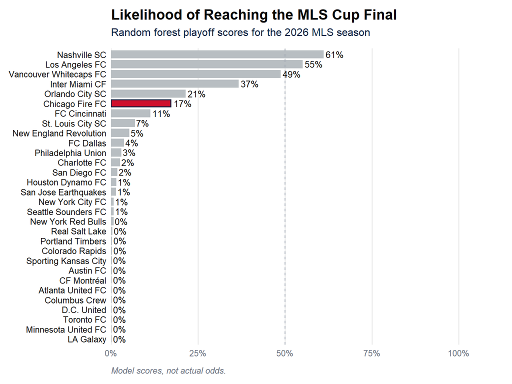

Figure 1: Random forest MLS Cup Final for the 2026 MLS season. Model scores, not calibrated odds.

```r
fire_red      <- "#CF102D"  # primary
fire_navy     <- "#0A2342"  # deep navy
fire_sky      <- "#99D6EA"  # chicago flag light blue highlight
fire_star_red <- "#E4002B"  # chicago star red
fire_black    <- "#0A0A0A"
muted_bar     <- "#B8BEC2"

finals_scores <- current_predictions %>%
  transmute(
    team,
    finals_score = .pred_Yes,
    is_fire = team == "Chicago Fire FC"
  ) %>%
  arrange(finals_score) %>%
  mutate(team = factor(team, levels = team))

ggplot(
  finals_scores,
  aes(x = finals_score, y = team, fill = is_fire, color = is_fire)
) +
  geom_col(width = 0.72, linewidth = 0.6) +
  geom_vline(
    xintercept = 0.5,
    linetype = "dashed",
    color = "#9CA3AF",
    linewidth = 0.5
  ) +
  geom_text(
    aes(label = scales::percent(finals_score, accuracy = 1)),
    hjust = -0.15,
    size = 3.6,
    color = fire_black
  ) +
  scale_x_continuous(
    labels = scales::percent_format(accuracy = 1),
    limits = c(0, 1.08),
    breaks = seq(0, 1, 0.25),
    expand = expansion(mult = c(0, 0.02))
  ) +
  scale_fill_manual(
    values = c(
      `TRUE`  = fire_red,   # highlight the Fire
      `FALSE` = muted_bar
    )
  ) +
  scale_color_manual(
    values = c(
      `TRUE`  = fire_navy,  # Fire outline
      `FALSE` = muted_bar
    )
  ) +
  labs(
    title = "Likelihood of Reaching the MLS Cup Final",
    subtitle = "Random forest playoff scores for the 2026 MLS season",
    caption = "Model scores, not actual odds.",
    x = NULL,
    y = NULL
  ) +
  theme_minimal(base_size = 12) +
  theme(
    legend.position = "none",
    plot.title = element_text(face = "bold", color = fire_black, size = 16),
    plot.subtitle = element_text(color = fire_navy, margin = margin(b = 12)),
    plot.caption = element_text(
      color = "#6B7280",
      hjust = 0,
      margin = margin(t = 10),
      face = "italic"
    ),
    axis.text.y = element_text(color = fire_black),
    axis.text.x = element_text(color = "#6B7280"),
    panel.grid.major.y = element_blank(),
    panel.grid.minor = element_blank(),
    panel.grid.major.x = element_line(color = "#EAEAEA"),
    plot.margin = margin(10, 20, 10, 10)
  )
```